# The Bell Curve

# Foundational Concepts

Well, the most famous shape of distributions, ever, is the bell-shaped curve, which is called the Gaussian or the normal distribution. So, the family of curves—the normal curves or the Gaussian curves—is the topic of this lecture.

```r
if (!caracas::has_sympy()) {
  caracas::install_sympy()
}
library(caracas)
library(sets)
library(tibble)
library(ggplot2)
library(dplyr)
```

```r
X = c(1:10)
Σ = function(xs, n=0) sum(xs, n)
μ = function(xs) Σ(xs)/length(xs)
σ_2 = function (xs) Σ((xs - μ(xs)))^2/ length(xs)
P = function(E, p) E/p
f = function(x=x) x
C = function(n, k) factorial(n)/(factorial(k)*factorial((n - k)))
def_sym("x", "y", "z", "n", "p", "k", "Lambda", "e", "sigma", "Sigma", "mu")
```

Two Gaussian distributions can differ in their means (centers). For example, in the histograms of the heights of men and the heights of women, the means of the two just shifted over. Two Gaussian distributions can differ in their spread, as well. For example, the batting averages in 1920 and 2000 are both approximately normal curves with approximately the same mean but differing in their spread or standard deviation.

The normal distribution has a speci c mathematical formula. The normal distribution’s formula has a formidable and complicated look:

```r
normal_sym = 1/(sigma*sqrt(2*pi)) * e^(-1/2*((x - mu)/sigma)^2)
normal_sym
```

```
c:                                 2
                      -0.5⋅(-μ + x)
                      ───────────────
                             2
                            σ
   0.398942280401433⋅e
   ──────────────────────────────────
                   σ
```

```r
numbers_vector = 1:9
faces_vector = c("Ace", "Jack", "Queen", "King")


card_deck_df <- tibble(card = c(faces_vector, numbers_vector), value = c(10, 11, 12, 13, numbers_vector))
```

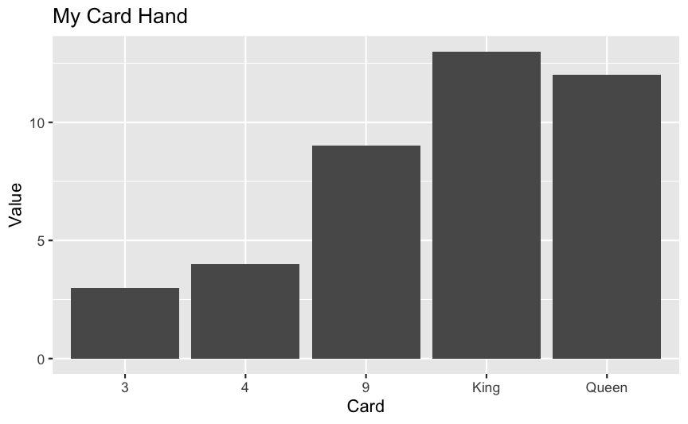

```r
card_hand_df <- card_deck_df |>
  slice_sample(n = 5)

ggplot(card_hand_df, aes(x = card, y = value)) +
  geom_col() +
  labs(
    title = "My Card Hand",
    x = "Card",
    y = "Value"
  )
```

```r
deck_mean <- mean(card_deck_df$value)
deck_mean
```

```
[1] 7
```

```r
sample_means_df_generator <-
  function(card_deck_df = card_deck_df, hand_size = 5,num_simulations = 10000) {
    tibble(means = purrr::map_dbl(1:num_simulations, \(x) card_deck_df |>
                                  slice_sample(n = hand_size, replace = FALSE) |>
                                  pull(value) |> mean()))
}
sample_means_df_generator(card_deck_df)
```

| means |
| --- |
| 7.8 |
| 7.6 |
| 8.6 |
| 6.2 |
| 9.0 |
| 6.4 |
| 5.4 |
| 8.2 |
| 8.4 |
| 7.6 |

[output cut: 990 more lines]

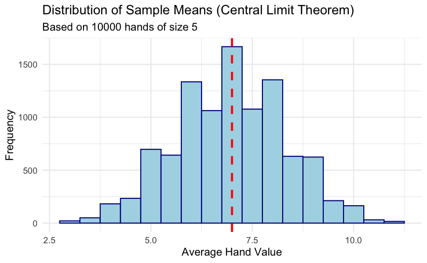

```r
ggplot(sample_means_df_generator(card_deck_df), aes(x = means)) +
  geom_histogram(binwidth = 0.5, fill = "lightblue", color = "darkblue") +
  geom_vline(xintercept = deck_mean, linetype = "dashed", color = "red", linewidth = 1) +
  labs(
    title = "Distribution of Sample Means (Central Limit Theorem)",
    subtitle = paste("Based on", 10000, "hands of size", 5),
    x = "Average Hand Value",
    y = "Frequency"
  ) +
  theme_minimal()
```

The central limit theorem says that starting with (almost) any distribution (such as a Poisson distribution, or a binomial distribution, or a uniform distribution), if we take many samples of size n, the distribution of the average values of the samples will be approximately a Gaussian distribution (assuming n is large). The standard deviation of the sample population will be the original population’s standard deviation divided by the square root of n. This fact will be useful in doing statistical inference. The approximation gets better and better as the sample size n gets larger and larger.

# Concept and Applications

## COVARIANCE AND CORRELATION

if you’re new to statistics, you may be ready to jump on the cause-and-effect bandwagon when you find a strong relationship between 2 variables. But have you ever thought about why 2 variables might be correlated? So far, when we’ve considered variance, we’ve limited ourselves to 1 variable. But what if we have 2 variables that we think might be related? How might they vary together? This brings us to the idea of covariance, and from there to correlation.

```r
X = c(2,3,5,6,8,9,10,13)
Y = c(58,75,71,77,80,88,83,95)
```

### COVARIANCE

```r
Cov <- function(X, Y, n = length(X)) sum((X - mean(X)) * (Y - mean(Y)) / (n - 1))

Cov(X,Y)
```

```
[1] 38
```

```r
cov(X, Y)
```

```
[1] 38
```

### CORRELATION

```r
Cor(X, Y)
```

```
[1] 0.9173286
```

```r
σ_2_sample(X)
```

[output not shown]

### CORRELATION AND COVARIANCE

```r
# not done yet!
data("Harman23.cor")
head(Harman23.cor$cov)
```

```
               height arm.span forearm lower.leg weight bitro.diameter chest.girth chest.width
height          1.000    0.846   0.805     0.859  0.473          0.398       0.301       0.382
arm.span        0.846    1.000   0.881     0.826  0.376          0.326       0.277       0.415
forearm         0.805    0.881   1.000     0.801  0.380          0.319       0.237       0.345
lower.leg       0.859    0.826   0.801     1.000  0.436          0.329       0.327       0.365
weight          0.473    0.376   0.380     0.436  1.000          0.762       0.730       0.629
bitro.diameter  0.398    0.326   0.319     0.329  0.762          1.000       0.583       0.577
```